# RÃ©gression Logistique

SÃ©ance 1

Florent Chuffart & Magali Richard (d’aprÃ¨s le cours de Lydiane Agier)

2019-11-15

## Cours

- https://github.com/magrichard/cours_reglog

## PrÃ©-requis

- R https://cran.r-project.org
- RStudio https://www.rstudio.com

## 3 Data Challenges

- *sexpred* : prÃ©dir le sexe de 100 patients Ã partir de 500 observations
- *histpred* : prédir l’histologie de 100 patients Ã partir de 500 observations
- *virpred* : prÃ©dir la virulence de 100 patients Ã partir de 500 observations

# Plan

## I. Régression linéaire (rappel)

Y est expliquée (modélisée) par les variables explicatives $X= (X_1,X_2,...,X_p)$.

Si $p=1$, câ€™est une fonction affine de X.

Modèle :
$$E(Y) = \beta X= \beta_0 + \beta_1X_1 + … + \beta_pX_p$$

avec $\beta=(\beta_0, \beta_1, …, \beta_p)$ estimé par les moindres carrées

$$\beta = argmin(\sum_{i=1}^{n} {(y_i - \beta_0 - \beta_1x_{1,i} - ... - \beta_px_{p,i})^2)}$$

Sous l’hypothèse de normalité des résidus, l’estimateur des moindres carrés est équivalent Ã l’estimateur du maximum de vraisemblance pour la régression linéaire :

- La valeur estimée (ajustée) de Y est $\widehat{y}_i = \widehat{\beta}_0 + \widehat{\beta}_1X_1 + … + \widehat{\beta}_pX_p$
- Les résidus sont estimés par $e_i = y_i -\widehat{y}_i$
- La variance du terme d’erreur est estimée par $s^2 = \frac{1}{n-2} \sum_{i=1}^{n}{e_i^2}$

## I) DonnÃ©es : data_nutri

```r
d = read.table("data/data_nutri.csv", header=TRUE, sep=",", row.names = 1)
d$sex = as.factor(d$sex)
DT::datatable(d, width = "100%")
```

|  | sexe | situation | the | cafe | taille | poids | age | viande | poisson | fruit_crus | fruit_legume_cuits | chocol | matgras | sex |
| --- | --- | --- | --- | --- | --- | --- | --- | --- | --- | --- | --- | --- | --- | --- |
| 1 | Femme | Vit seul | 0 | 0 | 151 | 58 | 72 | 4/6 1 fois/sem | 2/3 fois/sem | &lt;1 fois/sem | 4/6 1 fois/sem | Tous les jours | Isio4 | Femme |
| 2 | Femme | Vit seul | 1 | 1 | 162 | 60 | 68 | Tous les jours | 1 fois/sem | Tous les jours | Tous les jours | &lt;1 fois/sem | Tournesol | Femme |
| 3 | Femme | Vit seul | 0 | 4 | 162 | 75 | 78 | 2/3 fois/sem | &lt;1 fois/sem | Tous les jours | 1 fois/sem | Tous les jours | Tournesol | Femme |
| 4 | Femme | Vit seul | 0 | 0 | 154 | 45 | 91 | Jamais | 4/6 1 fois/sem | 4/6 1 fois/sem | Jamais | 2/3 fois/sem | Margarine | Femme |
| 5 | Femme | Vit seul | 2 | 1 | 154 | 50 | 65 | Tous les jours | 2/3 fois/sem | Tous les jours | Tous les jours | 2/3 fois/sem | Margarine | Femme |
| 6 | Femme | Vit seul | 2 | 0 | 159 | 66 | 82 | 4/6 1 fois/sem | 1 fois/sem | Tous les jours | Tous les jours | &lt;1 fois/sem | Arachide | Femme |
| 7 | Femme | Vit seul | 2 | 0 | 160 | 66 | 74 | 2/3 fois/sem | 2/3 fois/sem | Tous les jours | Tous les jours | Tous les jours | Isio4 | Femme |
| 8 | Femme | Vit seul | 0 | 2 | 163 | 66 | 73 | 4/6 1 fois/sem | 1 fois/sem | Tous les jours | Tous les jours | &lt;1 fois/sem | Isio4 | Femme |
| 9 | Femme | Vit seul | 0 | 3 | 154 | 60 | 89 | 4/6 1 fois/sem | 2/3 fois/sem | Tous les jours | Tous les jours | Tous les jours | Isio4 | Femme |
| 10 | Femme | Vit seul | 0 | 2 | 160 | 77 | 87 | 1 fois/sem | 2/3 fois/sem | Tous les jours | 4/6 1 fois/sem | Jamais | Arachide | Femme |

[output cut: 216 more lines]

```r
# head(d)
```

## I) Exemple 1

```r
# README RStudio config, uncheck: # preferences > R Markdown > show output inline for...
layout(matrix(1:2, 1, byrow=TRUE), respect=TRUE)
plot(d$taille, d$poids, main="poids~taille")
## Model
# Y~X
# E(Y) = b.X
# E(Y) = b_0 + b_1.X
# Y_i = b_0 + b_1.X_i + e_i
m = lm(d$poids~d$taille)
m$coefficients
```

```
## (Intercept)    d$taille
## -71.7196398   0.8428994
```

```r
abline(a=m$coefficients[[1]], b=m$coefficients[[2]], col=2) # /!\ y = b.x + a
# residuals
m$residuals
```

```
##            1            2            3            4            5
##   2.44182499  -4.83006881  10.16993119 -13.08687332  -8.08687332
##            6            7            8            9           10
##   3.69862950   2.85573007   0.32703176   1.91312668  13.85573007
##           11           12           13           14           15
##  -7.78776147   7.64123289  -8.45847106   4.07022725  21.91312668
##           16           17           18           19           20
##  11.79833345  -5.30137050  -5.61557163 -10.35876711  30.22732781
##           21           22           23           24           25
##  14.21223853   4.01283063  13.11253458  20.11253458  -3.77267219
##           26           27           28           29           30
##  -1.57326429  -6.83006881   6.74093684   7.64123289   8.58383627
##           31           32           33           34           35
##  -9.14426993   5.36933909 -13.51586768  -1.77267219  12.75602612
##           36           37           38           39           40
##   7.69862950 -11.57326429   8.68354022  12.74093684   9.94034474
##           41           42           43           44           45
##   7.11253458  13.15484192 -11.25906316  -8.14426993  -8.92977275
##           46           47           48           49           50
##   7.74093684  -1.14426993 -10.45847106 -14.14426993   3.48413232
##           51           52           53           54           55
##   2.75602612  -2.73036486  -2.35876711  -2.20166655   8.36933909
##           56           57           58           59           60
##  -1.00225865   0.05513797  -3.14426993   3.85573007  -4.74545414
##           61           62           63           64           65
##  19.85573007 -12.15935921  -3.61557163   9.25454586  -0.94486203
##           66           67           68           69           70
##   0.89803740  -3.14426993   0.28472442   4.42673571   9.99774135
##           71           72           73           74           75
##   3.59892555   9.16993119   7.59892555  22.64123289 -16.08687332
##           76           77           78           79           80
##   5.89803740   1.75602612 -25.78776147 -14.47356034   5.74093684
##           81           82           83           84           85
##   0.95543402  -6.92977275  -6.83006881  -5.77267219 -12.40107445
##           86           87           88           89           90
##  -1.77267219  -1.14426993  -2.57326429  13.48413232 -10.14426993
##           91           92           93           94           95
##  -0.78776147  -7.98716937   0.11253458   9.21223853  -0.05965526
##           96           97           98           99          100
##  -1.63066091  11.54152894  -0.04456598 -22.05965526  -0.35876711
```

[output cut: 37 more lines]

```
##   8.22732781  17.74093684  10.16993119  -6.71527558   1.85573007
##          196          197          198          199          200
##  -2.40107445 -13.35876711   4.07022725  -2.88746542   4.91312668
##          201          202          203          204          205
##  -2.63066091  -5.08687332  -2.88746542  -4.67296824   2.52643966
##          206          207          208          209          210
##   3.11253458  -7.41616373  -1.14426993  -5.88746542 -15.14426993
##          211          212          213          214          215
## -10.47356034  16.85573007   8.64123289  19.38442837  -3.63066091
##          216          217          218          219          220
##  -7.55817501  -4.24397388  -3.35876711  12.58383627   6.95543402
##          221          222          223          224          225
##  -2.61557163   9.85573007  -3.67296824   2.42673571 -13.08687332
##          226
##   0.69862950
```

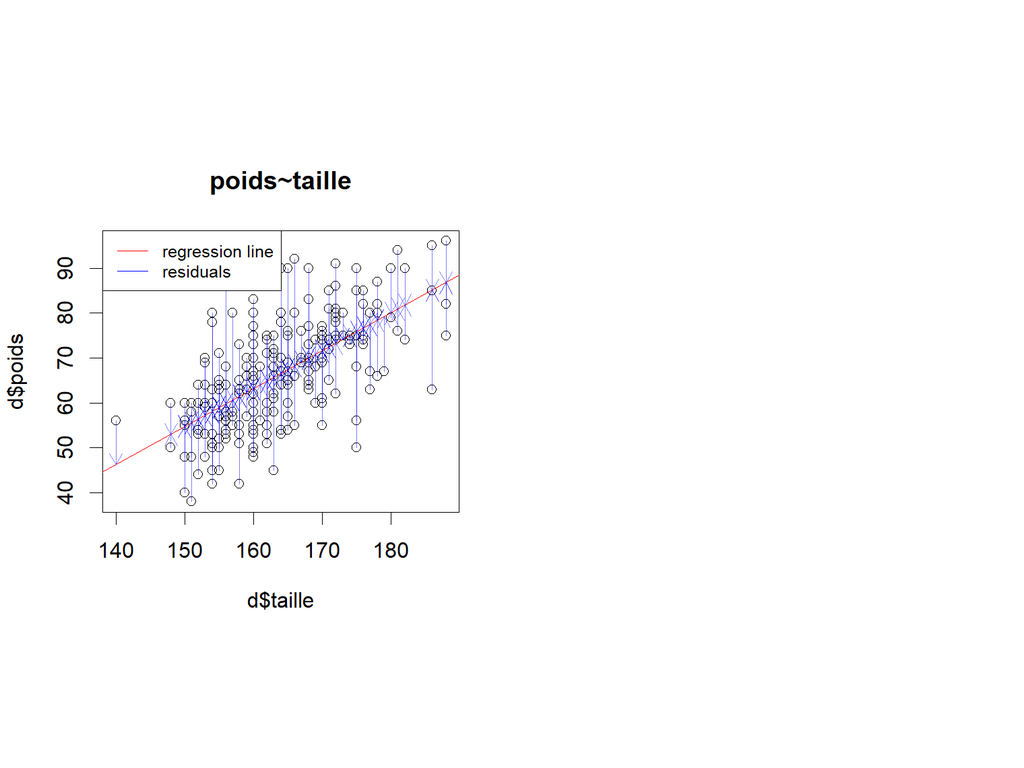

```r
arrows(d$taille, d$poids, d$taille, d$poids-m$residuals, col=adjustcolor(4, alpha.f=0.5), length=0.1)
legend("topleft",c("regression line", "residuals"), col=c(2,4), lty=1, cex=.8)
```

## I) Exemple 2

```r
layout(matrix(1:2, 1), respect=TRUE)
plot(d$sex, d$poids, main="poids~sex", xlab="sex", ylab="poids")
## Model
# Y~X
# E(Y) = b.X
# E(Y) = b_0 + b_1.X
# Y_i = b_0 + b_1.X_i + e_i
m = lm(d$poids~d$sex)
m$coefficients
```

```
## (Intercept)  d$sexHomme
##    61.10638    14.29362
```

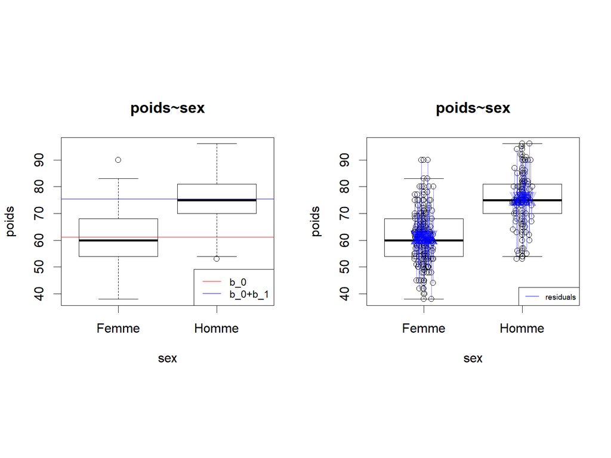

```r
abline(h=m$coefficients[[1]], col=2)
abline(h=m$coefficients[[1]] + m$coefficients[[2]], col=4)
legend("bottomright",c("b_0", "b_0+b_1"), col=c(2,4), lty=1, cex=.8)

plot(d$sex, d$poids, main="poids~sex", xlab="sex", ylab="poids")
points(as.numeric(d$sex), d$poids)
x = jitter(as.numeric(d$sex), 0.5)
points(x, d$poids)
arrows(x, d$poids, x, d$poids-m$residuals, col=adjustcolor(4, alpha.f=0.5), length=0.1)
legend("bottomright",c("residuals"), col=c(4), lty=1, cex=0.6)
```

```r
# t.test
# 1 null hypothesis
# H_0: p_h==_f
# H_1: p_h!=p_f
# 2 risk
# alpha = 5%
# 3 test hypothesis
# residuals~N?
shapiro.test(d[d$sex=="Femme",]$poids)
```

```
##
##  Shapiro-Wilk normality test
##
## data:  d[d$sex == "Femme", ]$poids
## W = 0.9903, p-value = 0.4388
```

```r
shapiro.test(d[d$sex=="Homme",]$poids)
```

```
##
##  Shapiro-Wilk normality test
##
## data:  d[d$sex == "Homme", ]$poids
## W = 0.97428, p-value = 0.087
```

```r
# -> OK
# 4 t.test
t.test(d[d$sex=="Femme",]$poids, d[d$sex=="Homme",]$poids)
```

```
##
##  Welch Two Sample t-test
##
## data:  d[d$sex == "Femme", ]$poids and d[d$sex == "Homme", ]$poids
## t = -10.613, df = 179.77, p-value < 2.2e-16
## alternative hypothesis: true difference in means is not equal to 0
## 95 percent confidence interval:
##  -16.95113 -11.63611
## sample estimates:
## mean of x mean of y
##  61.10638  75.40000
```

```r
anova(m)
```

```
## Analysis of Variance Table
##
## Response: d$poids
##            Df Sum Sq Mean Sq F value    Pr(>F)
## d$sex       1  10835 10834.6  111.61 < 2.2e-16 ***
## Residuals 224  21746    97.1
## ---
## Signif. codes:  0 '***' 0.001 '**' 0.01 '*' 0.05 '.' 0.1 ' ' 1
```

```r
# 5 conclusion
```

## II) Introduction Ã la regression logistique : objectifs

Objectif : Modéliser une **variable binaire** en fonction d’une ou plusieurs autres covariables (quali ou quanti)
$$Y \sim X$$
$$E(Y|X) \sim X$$

Exemple de variable Ã expliquer :

- Le sexe en fonction du poids
- Maladie coronarienne en fonction d’HTA et cholestérol
- Survenue de cancer en fonction dâ€™expositions chimiques
- Consommation d’un bien selon variables sociodémographiques
- Risque d’accoucher d’un bébé de faible poids (<2500g) en fonction de l’âge de la mère, du poids, du tabagisme.
- le sexe en fonction de l’expression des gènes (challenge *sexpred*)
- l’histoplogie en fonction de l’expression des gènes (challenge *histpred*)
- la survie Ã 24 mois en fonction de l’expression des gènes (challenge *virpred*)

## II) Exemple 3

```r
layout(matrix(1:2, 1), respect=TRUE)
s = as.numeric(d$sex) - 1
plot(d$poids, s, main="sex~poids", xlab="poids", ylab="sex")
## Model
# Y~X
# E(Y) = b.X
# E(Y) = b_0 + b_1.X
# Y_i = b_0 + b_1.X_i + e_i
m = lm(s~d$poids)
m$coefficients
```

```
## (Intercept)     d$poids
## -1.17064686  0.02326564
```

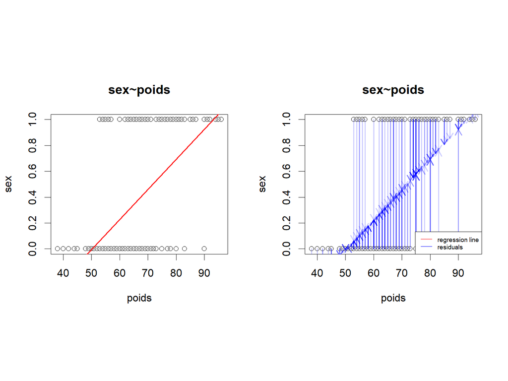

```r
abline(a=m$coefficients[[1]], b=m$coefficients[[2]], col=2, lwd=2) # /!\ y = b.x + a
plot(d$poids, s, main="sex~poids", xlab="poids", ylab="sex")
# residuals
arrows(d$poids, s, d$poids, s-m$residuals, col=adjustcolor(4, alpha.f=0.2), length=0.1, lwd=2)
legend("bottomright",c("regression line", "residuals"), col=c(2,4), lty=1, cex=0.6)
```

## III) Formalisme :

### Variable de Bernoulli

- Toute variable binaire peut être **codée en 0/1**, et est alors considérée comme une Variable de Bernoulli de distribution:

$$P(Y=1)=p$$
$$P(Y=0)=1-p$$
$$P(Y=k)=p^k(1-p)^{1-k}, k \in \{0,1\}$$

### Principe

- On pose Y la variable binaire,
- X le vecteur des covariables/variables explicatives (qualitatives ou quantitatives)
- On veut modéliser $E(Y|X) = f(X)$ avec $E(Y|X) = P(Y=1|X)$ noté $\pi (X)$

## III) Formalisme :

### Fonction logit

$$\begin{eqnarray}
\text{logit: } ]0,1[ & \rightarrow & \mathbb{R} \\
x & \rightarrow & logit(x) = log(\frac{x}{1-x}) \\
\end{eqnarray}$$

$$\lim_{x\to0} logit(x) = -\infty$$
$$\lim_{x\to1} logit(x) = +\infty$$

La fonction *logit* sâ€™inverse :

$$\begin{eqnarray}
\text{logit: } \mathbb{R}& \rightarrow & ]0,1[ \\
y & \rightarrow & logit^{-1}(y) = \frac{1}{1+e^{-y}}
\end{eqnarray}$$

## III) Exemple 4 : la fonction logit

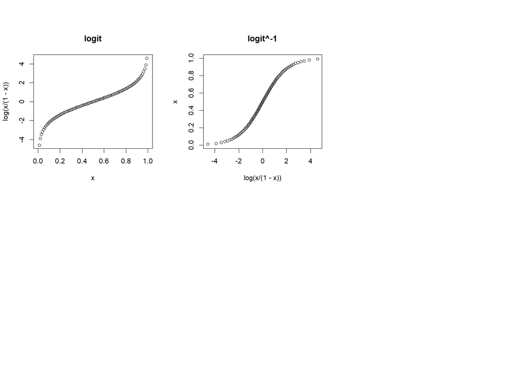

```r
# logit: [0,1] -> R
#            p -> log(p/1-p)
# logit(p) = log(p/1-p)
x = 0:100/100
layout(matrix(1:6, 2, byrow=TRUE), respect=TRUE)
plot(x, log(x/(1-x)), main="logit")
plot(log(x/(1-x)), x, main="logit^-1")
```

## III) Formalisme : le modÃ¨le logistique

On utilise donc le modÃ¨le logistique:
$$logit(E(Y|X)) = \beta X$$
$$logit(P(Y=1|X))= \beta X$$
$$logit(\pi (X))= \beta X$$
$$\pi (X)= logit^{-1}(\beta X)$$

On obtient ainsi $\pi(X)$, le prÃ©dicteur de Y en fonction de X.

Comme en régression linéaire, l’objet de cette modélisation est *d’estimer les coefficients $\beta$*

## III) Exemple 5 : le modÃ¨le logistique

```r
layout(matrix(1:2, 1), respect=TRUE)
plot(d$poids, s, main="sex~poids", xlab="poids", ylab="sex")
# P(Y=1|X) = logitinv(a + b.x)
m = glm(s~d$poids, family = binomial(logit))
m$coefficients
```

```
## (Intercept)     d$poids
## -10.2084669   0.1421788
```

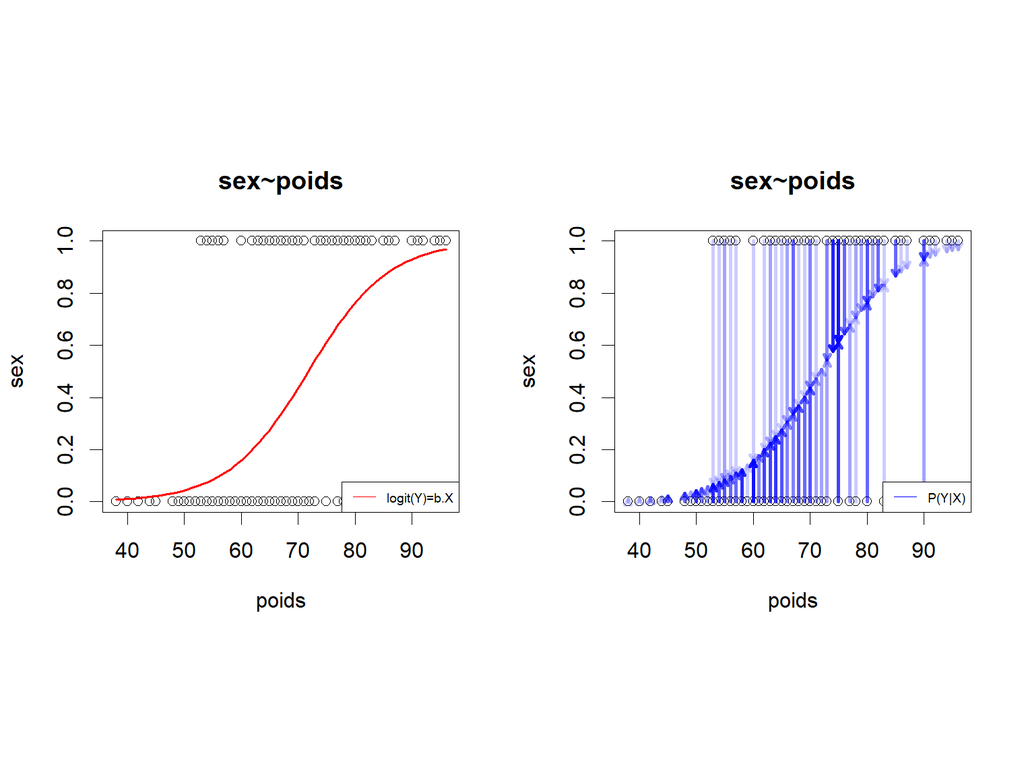

```r
logitinv = function(x) 1/(1 + exp(-x))
x = min(d$poids):max(d$poids)
lines(x, logitinv(m$coefficients[[1]] + m$coefficients[[2]]*x), col=2, lwd=2)
legend("bottomright", "logit(Y)=b.X", col=2, lty=1, cex=0.6)
plot(d$poids, s, main="sex~poids", xlab="poids", ylab="sex")
py1x = function(t,m) {
  x = m$coefficients[[1]] + m$coefficients[[2]]*t
  1/(1 + exp(-x))
}
arrows(d$poids, s, d$poids, py1x(d$poids,m), col=adjustcolor(4, alpha.f=0.2), length=0.05, lwd=3)
legend("bottomright","P(Y|X)", col=4, lty=1, cex=0.6)
```

## IV) Estimation : la vraisemblance

- **Définition** : Probabilité d’observer un évènement si le modèle envisagé est vrai
- La fonction de vraisemblance dÃ©pend de la distribution de $Y$
- On note les covariables globales théoriques: $X=(X_1,...,X_p)$ et observées : $x=(x_1,...,x_p)$. Les covariables individuelles observées sont notées : $x_i=(x_{1i},...,x_{pi})$
- Le modÃ¨le conditionnel de $Y$ sachant $X$ est : $E(Y|X = x) \sim B(\pi(x))$
- Pour lâ€™observation $i$, la contribution Ã la vraisemblance est donc:
  $$l(x_i, y_i) = P(y_i = 1|x_i)^{y_i} (1-P(y_i=1|x_i))^{1-y_i} = \pi(x_i)^{y_i}(1-\pi(x_i))^{1-y_i}$$

## IV) Estimation : les coefficients (1/2)

- Le modèle s’écrit: $logit(E(Y|X_1,...,X_p)) = \beta_0 + \beta_1X_1+...+\beta_pX_p$ Les paramètres $\beta = (\beta_0,\beta_1, ..., \beta_p)$ sont inconnus
- On estime $\beta$ par **maximum de vraisemblance**.
- La vraisemblance conditionnelle est:
  $$\prod_{i=1}^{n} l(x_i, y_i) = \prod_{i=1}^{n} \pi(x_i)^{y_i}(1-\pi(x_i))^{1-y_i} = \prod_{i=1}^{n} \Big(\frac{\pi(x_i)}{1-\pi(x_i)}\Big)^{y_i}(1-\pi(x_i))$$

## IV) Estimation : les coefficients (2/2)

- La vraisemblance conditionnelle est:
  $$\prod_{i=1}^{n} l(x_i, y_i) = \prod_{i=1}^{n} \pi(x_i)^{y_i}(1-\pi(x_i))^{1-y_i} = \prod_{i=1}^{n} \Big(\frac{\pi(x_i)}{1-\pi(x_i)}\Big)^{y_i}(1-\pi(x_i))$$
- En passant au logarithme, on a :

$$log(L_n(\beta)) = \sum_{i=1}^{n}\Big[ y_i * log \Big(\frac{\pi(x_i)}{1-\pi(x_i)}\Big) + log(1-\pi(x_i))\Big]$$

- Cette fonction contient des valeurs observées $y_i$ et des valeurs prédites $\pi(x_i)$ qui dépendent de $\beta$
- On maximise cette fonction en trouvant la valeur de $\beta$ *pour laquelle la dérivée (par rapport Ã $\beta$) est nulle* : $L_n'(\beta) = 0$, definissant ainsi :
  $$\widehat{\beta}_n = argmax L_n(\beta)$$

## IV) Estimation : remarques

- Il nâ€™existe pas de **solution analytique** de $L_n'(\beta) = 0$
- L’estimation de $\widehat{\beta}$ est donc fait **par approximation** (d’où des résultats potentiellement différents selon l’algorithme), avec souvent la démarche suivante:
1. Le logiciel propose une première valeur pour $\beta$ et calcule la vraisemblance associée
2. Il cherche de nouvelles valeurs «plausibles» pour $\beta$ et voit si elles améliorent la vraisemblance
3. Et réitère cela jusqu’Ã atteindre une condition, eg. la différence de vraisemblance est <0.00001
- L’estimateur $\widehat{\beta}$ est estimé par le modèle, et non pas observé: sa valeur **dépend du modèle utilisé et de la validité de celui-ci**.

## IV) Estimation : Propriétés de l’estimateur (1/2)

- Asymptotiquement (i.e quand n tend vers l’infini), lâ€™estimateur du maximum de vraisemblance:
1. existe et est unique
2. est sans biais (i.e. il tend vers sa valeur rÃ©elle)
3. est de distribution normale
4. est efficace (i.e. de variance minimale parmi tous les estimateurs sans biais obtenus avec d’autres méthodes).
- Ainsi: $\lim_{n\to\infty} \sqrt{n}(\widehat{\beta}-\beta) \rightarrow N(0,\Sigma^{-1})$ avec $\Sigma^{-1}$ la matrice de variance-covariance de $\beta$

## IV) Estimation : Propriétés de l’estimateur (2/2)

- On en dÃ©duit les **intervalles de confiance** pour $\beta_k$:

$$IC(\widehat{\beta}) = \Big[\widehat{\beta_k} -t_{1-\alpha/2,n-2} * \sqrt{\widehat{var}(\widehat{\beta_k})} ; \widehat{\beta_k}+t_{1-\alpha/2,n-2} * \sqrt{\widehat{var}(\widehat{\beta_k})} \Big]$$

Avec $t_{1-\alpha/2,n-2}$ le quantile de niveau $1-\alpha/2$ de la loi de student Ã (n-2) degrés de liberté

En pratique approximé dès que $n>30$ par $u1-\alpha/2$ le quantile de niveau $1-\alpha/2$ de la loi normale

## IV) Estimation : Valeurs prédites et résidus

A partir de $\widehat{\beta}$ , on peut calculer:

1. les **valeurs prÃ©dites** : $\pi(X)$

i.e. la probabilité estimée de $Y=1$ pour chaque individu en fonction de ses caractéristiques

2. les **rÃ©sidus** : $\epsilon = Y - \widehat{\pi}(X)$

Ceux-ci peuvent servir Ã estimer l’adéquation du modèle aux données (vus plus loin)

# Exemple 6

```r
m = glm(s~d$poids+d$taille+d$age, family = binomial(logit))
m$coefficients
```

```
##   (Intercept)       d$poids      d$taille         d$age
## -6.258665e+01  8.207462e-02  3.414538e-01 -5.100202e-04
```

```r
summary(m)
```

```
##
## Call:
## glm(formula = s ~ d$poids + d$taille + d$age, family = binomial(logit))
##
## Deviance Residuals:
##      Min        1Q    Median        3Q       Max
## -2.35258  -0.34058  -0.08738   0.26276   2.64806
##
## Coefficients:
##              Estimate Std. Error z value Pr(>|z|)
## (Intercept) -62.58665    9.23157  -6.780 1.20e-11 ***
## d$poids       0.08207    0.02656   3.090    0.002 **
## d$taille      0.34145    0.05258   6.493 8.39e-11 ***
## d$age        -0.00051    0.03849  -0.013    0.989
## ---
## Signif. codes:  0 '***' 0.001 '**' 0.01 '*' 0.05 '.' 0.1 ' ' 1
##
## (Dispersion parameter for binomial family taken to be 1)
##
##     Null deviance: 299.28  on 225  degrees of freedom
## Residual deviance: 118.75  on 222  degrees of freedom
## AIC: 126.75
##
## Number of Fisher Scoring iterations: 6
```

```r
layout(matrix(1:2, 1, byrow=TRUE), respect=TRUE)
plot(d$taille, d$poids, main="poids~taille", col=s+1)
## Model
# Y~X
# E(Y) = b.X
# E(Y) = b_0 + b_1.X
# Y_i = b_0 + b_1.X_i + e_i
m = lm(d$poids~d$taille)
m$coefficients
```

```
## (Intercept)    d$taille
## -71.7196398   0.8428994
```

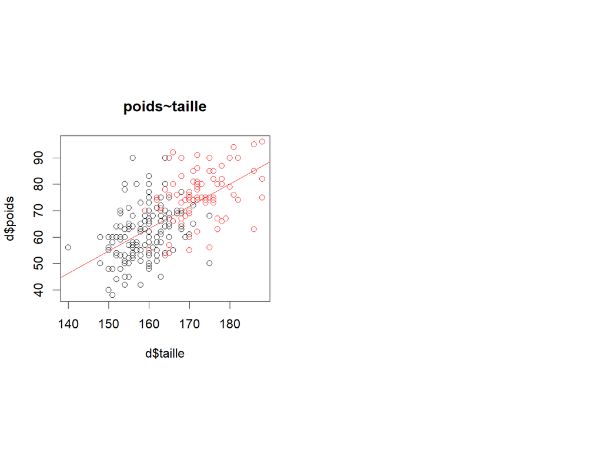

```r
abline(a=m$coefficients[[1]], b=m$coefficients[[2]], col=2) # /!\ y = b.x



layout(matrix(1:2, 1), respect=TRUE)
```

```r
plot(d$poids, s, main="sex~poids", xlab="poids", ylab="sex")
# P(Y=1|X) = logitinv(a + b.x)
m = glm(s~d$poids, family = binomial(logit))
m$coefficients
```

```
## (Intercept)     d$poids
## -10.2084669   0.1421788
```

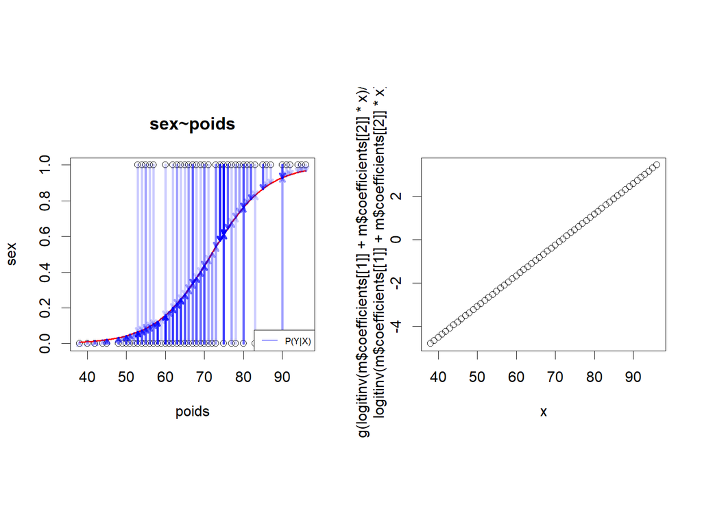

```r
logitinv = function(x) 1/(1 + exp(-x))
x = min(d$poids):max(d$poids)
lines(x, logitinv(m$coefficients[[1]] + m$coefficients[[2]]*x), col=2, lwd=2)
py1x = function(t,m) {
  x = m$coefficients[[1]] + m$coefficients[[2]]*t
  1/(1 + exp(-x))
}
arrows(d$poids, s, d$poids, py1x(d$poids,m), col=adjustcolor(4, alpha.f=0.2), length=0.05, lwd=3)
legend("bottomright","P(Y|X)", col=4, lty=1, cex=0.6)


x = min(d$poids):max(d$poids)
plot(x,log(logitinv(m$coefficients[[1]] + m$coefficients[[2]]*x) / (1-logitinv(m$coefficients[[1]] + m$coefficients[[2]]*x))))
```

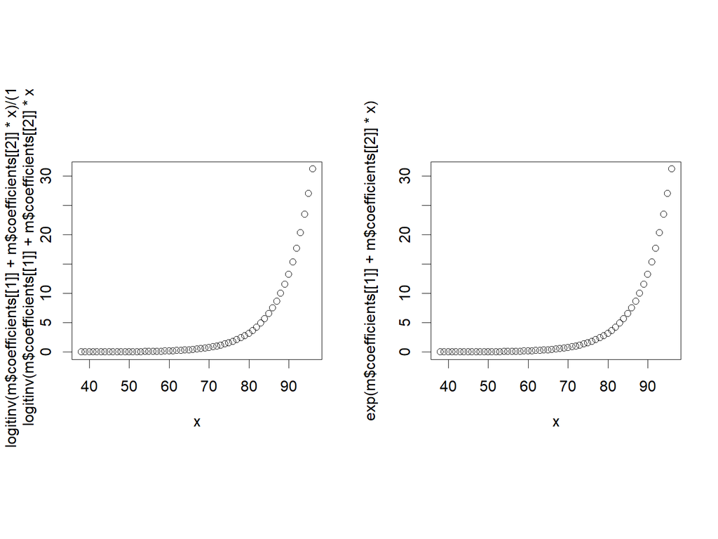

```r
plot(x,logitinv(m$coefficients[[1]] + m$coefficients[[2]]*x) / (1-logitinv(m$coefficients[[1]] + m$coefficients[[2]]*x)))
plot(x,exp(m$coefficients[[1]] + m$coefficients[[2]]*x))
```

```r
x = 72
logitinv(m$coefficients[[1]] + m$coefficients[[2]]*x) / (1-logitinv(m$coefficients[[1]] + m$coefficients[[2]]*x))
```

```
## [1] 1.028812
```

```r
plot(d$taille, s, main="sex~taille", xlab="taille", ylab="sex")
# P(Y=1|X) = logitinv(a + b.x)
m = glm(s~d$taille, family = binomial(logit))
m$coefficients
```

```
## (Intercept)    d$taille
## -63.4916160   0.3809816
```

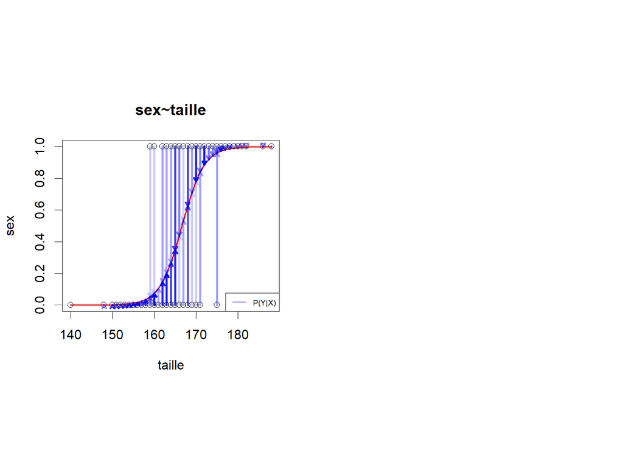

```r
logitinv = function(x) 1/(1 + exp(-x))
x = min(d$taille):max(d$taille)
lines(x, logitinv(m$coefficients[[1]] + m$coefficients[[2]]*x), col=2, lwd=2)
py1x = function(t,m) {
  x = m$coefficients[[1]] + m$coefficients[[2]]*t
  1/(1 + exp(-x))
}
arrows(d$taille, s, d$taille, py1x(d$taille,m), col=adjustcolor(4, alpha.f=0.2), length=0.05, lwd=3)
legend("bottomright","P(Y|X)", col=4, lty=1, cex=0.6)
```

## V) Test de significativité des paramètres

- On veut tester lâ€™influence de $X_k$. On teste:
  $$H_0 : {\beta_k = 0}$$
  vs.
  $$H_1 : {\beta_k \neq 0}$$
- Il existe 3 tests:
1. Test de Wald
2. Test du score (peu utilisÃ©, pas vu ici)
3. Test du rapport de vraisemblance (pour modèles emboités)

## V) Test de Wald

$$\sqrt{n\Sigma^{1/2}}(\widehat{\beta}-\beta) \rightarrow \mathcal{N}(0,I_p)$$
$$T =n(\widehat\beta-\beta)'\widehat\Sigma^{-1}(\widehat\beta-\beta) \xrightarrow[]{L} \mathcal{X}^2_p$$
avec $n$ le nombre d’observations et $p$ le nombre de paramètres testés.

Rq, pour un unique paramÃ¨tre on a $T = \Big(\frac {\widehat\beta_k} {\widehat\sigma_{\widehat\beta_k}}\Big)^2 \sim \mathcal{X}^2_p$

- On rejette $H_0$ si:
  $$T>z^p_{1-\alpha}$$
  avec $z^p_{1-\alpha}$ le quantile de niveau $(1-\alpha)$ de la loi de $\mathcal{X}^2$ Ã $p$ ddl.

## V) Exemple Test de Wald

```r
m = glm(s~d$poids+d$taille+d$age, family = binomial(logit))
m$coefficients
```

```
##   (Intercept)       d$poids      d$taille         d$age
## -6.258665e+01  8.207462e-02  3.414538e-01 -5.100202e-04
```

```r
summary(m)$coefficient
```

```
##                  Estimate Std. Error     z value     Pr(>|z|)
## (Intercept) -6.258665e+01 9.23156931 -6.77963325 1.204813e-11
## d$poids      8.207462e-02 0.02655953  3.09021333 2.000128e-03
## d$taille     3.414538e-01 0.05258426  6.49346082 8.388659e-11
## d$age       -5.100202e-04 0.03848904 -0.01325105 9.894275e-01
```

```r
#Wald test for weight effect
summary(m)$coefficient[2,4]
```

```
## [1] 0.002000128
```

```r
#Wald test for size effect
summary(m)$coefficient[3,4]
```

```
## [1] 8.388659e-11
```

```r
#Wald test for age effect
summary(m)$coefficient[4,4]
```

```
## [1] 0.9894275
```

```r
library(aod)
varEst = summary(m1)$cov.unscaled
Est = summary(m1)$coefficient[,1]
Est
#wald test for age
wald.test(Sigma = varEst, b = Est , Terms = 4)
```

[output not shown]

## V) Test du rapport de vraisemblance

Soit mod1 un modèle emboité dans mod2 (i.e. toutes les variables dans mod1 sont dans mod2) avec mod2 qui comprend $p$ variables explicatives supplémentaires par rapport Ã mod1 avec:

$L1$ la valeur de vraisemblance de mod1 et $L2$ la valeur de vraisemblance de mod2. On a:

$$T = -2[log(L_1) - log(L_2)] \rightarrow \mathcal{X}^2_p$$
Rq: On appelle $D= - 2 log(L1))$ la dÃ©viance pour mod1

*!! Il faut que ces modèles soient appliquées aux même observations (entre autres, pas de données manquantes)*

- On rejette $H_0$ si:
  $$T>z^p_{1-\alpha}$$
  avec $z^p_{1-\alpha}$ le quantile de niveau $(1-\alpha)$ de la loi de $\mathcal{X}^2$ Ã $p$ ddl.

*!! Il faut que l’ajout des $p$ variables apportent suffisamment au modèle pour être considérées «utiles»*

## V) Exemple Test du rapport de vraisemblance

$H_0 : {\beta_{age} = 0}$ vs. $H_1 : {\beta_{age} \neq 0}$

```r
m1 = glm(s~d$poids+d$taille+d$age, family = binomial(logit))
m2 = glm(s~d$poids+d$taille, family = binomial(logit))
anova(m2, m1, test="Chisq")
```

```
## Analysis of Deviance Table
##
## Model 1: s ~ d$poids + d$taille
## Model 2: s ~ d$poids + d$taille + d$age
##   Resid. Df Resid. Dev Df  Deviance Pr(>Chi)
## 1       223     118.75
## 2       222     118.75  1 0.0001756   0.9894
```

$H_0 : {(\beta_{poids}, \beta_{age}) = (0,0)}$ vs. $H_1 :{(\beta_{poids}, \beta_{age}) \neq (0,0)}$

```r
m1 = glm(s~d$poids+d$taille+d$age, family = binomial(logit))
m2 = glm(s~d$taille, family = binomial(logit))
anova(m2, m1, test="Chisq")
```

```
## Analysis of Deviance Table
##
## Model 1: s ~ d$taille
## Model 2: s ~ d$poids + d$taille + d$age
##   Resid. Df Resid. Dev Df Deviance Pr(>Chi)
## 1       224     129.36
## 2       222     118.75  2   10.609 0.004969 **
## ---
## Signif. codes:  0 '***' 0.001 '**' 0.01 '*' 0.05 '.' 0.1 ' ' 1
```

```r
library(aod)
varEst = summary(m1)$cov.unscaled
Est = summary(m1)$coefficient[,1]
Est
#wald test for age
wald.test(Sigma = varEst, b = Est , Terms = c(1,3)
```

[output not shown]

## V) Comment utiliser les tests de significativitÃ©?

- Ces tests peuvent être utilisés pour **comparer des modèles**, et décider s’il faut ou non inclure une variable dans notre modèle explicatif de Y.
- Ils sont aussi utiles pour **tester une variable catégorielle** en testant conjointement toutes ses catégories

Rappels sur les tests

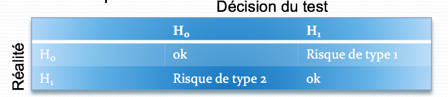

- Souvent dans les tests, on cherche Ã contrÃ´ler le risque de type 1, au niveau $\alpha$.

Si on a p-valeur du test=4%, c’est que si $H_0$ est vrai, et qu’on répétait la simulation 100 fois, on aurait obtenu 4 fois une valeur de statistique de test égale ou plus extrême que celle observée.

## sexpred

https://competitions.codalab.org/competitions/21853?secret_key=b50bf124-3513-4190-9397-ddd6c2561aea